# The current healthcare provision in the Mid and South Essex STP - part I

The Mid and South Essex region is a particularly important region of the health economy, owing to the fact that it is one of three regions in England currently engaged in a Success Regime. The NHS Five Year Forward View introduced Success Regimes as tools designed to provide assistance and encourage system-wide transformation in healthcare economies that have experienced long-standing performance and financial difficulties. The two other regions that are part of a Success Regime are Northern, Eastern and Western Devon and North Cumbria. However, both areas are far less densely populated than Essex (ranking 39<sup>th</sup> and 47<sup>th</sup>, respectively, compared to Essex that ranks 15<sup>th</sup>) and, therefore any system transformations in those two regions will impact fewer healthcare users<sup>1</sup>.

This makes the Mid and South Essex region an interesting area to explore and one that will receive an ever-increasing amount of scrutiny from various perspectives, including regulators, central government, the media and the public. This will be especially true in the coming years as people try to evaluate whether Success Regimes, as a tool, are effective at helping regions overcome long-standing system issues. Before any of the major transformations happen, it is important to get an understanding of the current healthcare provision in the area. This initial overview could later form the baseline from which to evaluate the effectiveness of the future transformations.

To understand any health economy it is necessary to examine, sometimes competing, factors. Consideration should not only be given to the individual components but also their interdependencies. While this statement might appear obvious it is often the case that policies seek to address a single issue or area, without necessarily considering the impact on, and influences of, the wider system. To some extent this is also how the performance of healthcare systems are evaluated and monitored. For example, CQC ratings are carried out at the individual provider level - no system wide or aggregated service provision ratings are provided, such as an overall GP provision rating for a given area. Even the 95% four-hour A&E performance target, that will reflect issues in the wider system, does not take these into account, instead placing the responsibility of poor performance firmly on the acute trust.

To assist us in exploring the Mid and South Essex health economy we will focus on five factors, while these factors will not explain the entirety of the system they should enable us to gain valuable insights into the region. Naturally, for our first factor, we will want to consider the population in the region, we will also want to examine the care provision in the area and will break this down into three factors: primary (GPs), acute (hospitals) and social care (nursing and care homes). Our fifth, and final, factor will explore the proximity of care to the population.

This first part in this series of posts will expand upon the goals of the Sustainability and Transformation Partnerships (STP) and examine the first of the factors listed above - the population in the region. This part will explore where the population live, how old they are and their socio-economic make-up.

## Sustainability and Transformation Partnerships

The NHS Five Year Forward plan, split the whole of England up into 44 Sustainability and Transformation Partnerships (STPs)<sup>2</sup>. Three of these STP areas were also designated as Success Regime areas, including the Mid and South Essex STP. Success regimes differ to STPs in the fact that issues are deep-rooted and that any transformation would be difficult, therefore, Success Regimes would receive additional national support to identify these issues and accelerate transformation.

All STPs share a common goal of closing the gap in three challenging aspects of health care, namely, the health and well-being gap, the care and quality gap and the funding and efficiency gap. Each STP area published their initial plan for transformation in 2016<sup>3</sup>.

Sustainability and Transformation Partnerships are not formal organisations, but rather, as the name indicates, partnerships amongst healthcare and local government organisations. These include hospitals, Clinical Commissioning Groups (CCGs), local councils and NHS England, amongst others. For the Mid and South Essex STP this partnership includes five CCGs (Basildon and Brentwood, Castle Point and Rochford, Mid Essex, Southend and Thurrock), three local authorities (Essex County Council, Southend-on-Sea Borough Council and Thurrock Council), three acute trusts (Basildon and Thurrock University Hospitals NHS Foundation Trust, Mid Essex Hospital Services NHS Trust and Southend University Hospital NHS Foundation Trust), the East of England Ambulance service, as well as NHS England and NHS Improvement<sup>4</sup>.

In total, the Success Regime area covers more than 1 million health care users and has an annual budget of approximately £2,500 million a year (16/17)<sup>5</sup>. Figure 1 outlines the area covered by the Mid and South Essex STP, including the main population centres and highlights the various CCGs involved and their respective geographical areas.

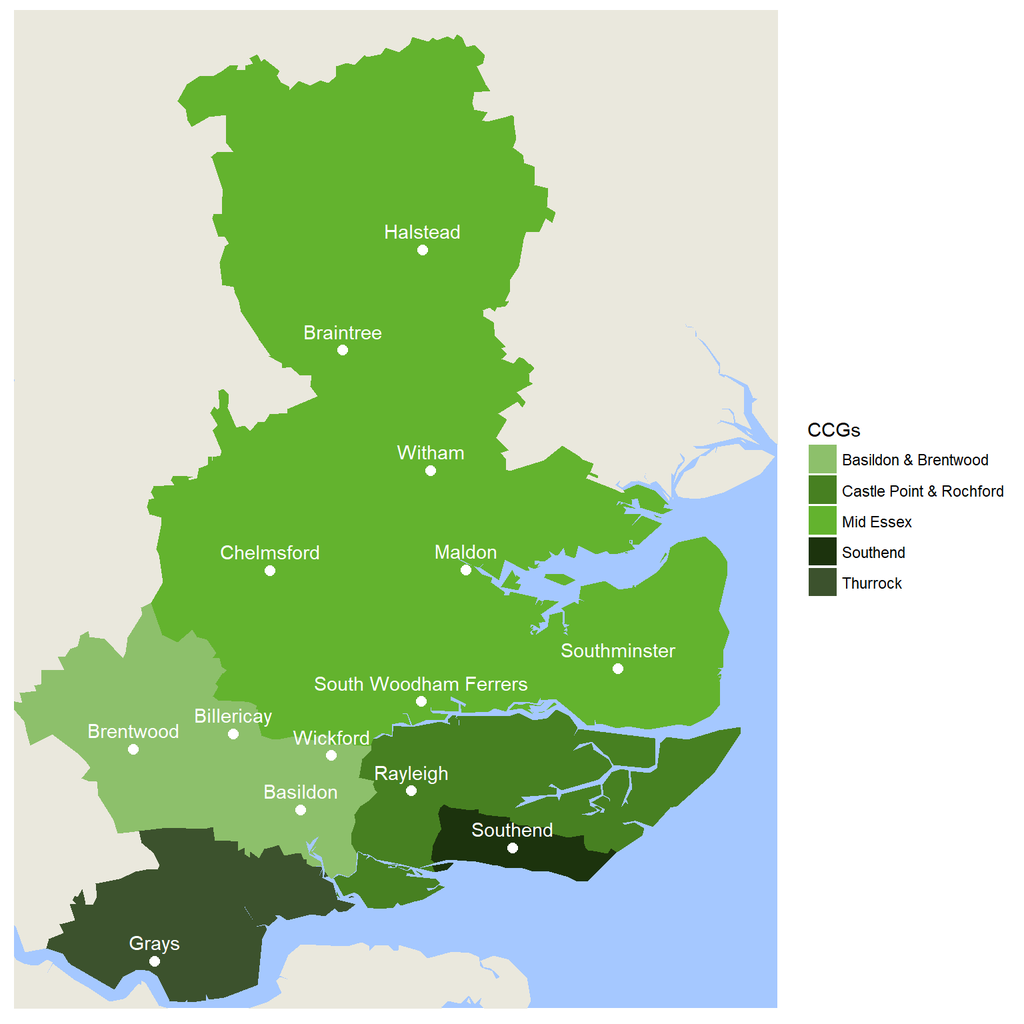

**Figure 1**: Map of the Mid and South Essex STP area

<sup>Contains OS data © Crown copyright and database right (2018)</sup> <sup>Source: Office for National Statistics</sup> <sup>Contains public sector information licensed under the Open Government Licence v3.0.</sup>

# The population (the demand)

### Population density - where people live

Any healthcare system needs to be able to provide care services throughout the region it serves. As stated above, the Mid and South Essex STP has more than 1 million health care users and covers an area just shy of 200,000 hectares (or just over 280,000 football pitches). In many regions the population tends to be unevenly distributed, with the population concentrated around key towns and cities. As such, it is important to analyse how the STP’s population is distributed to get a better understanding of where the population clusters are. These clusters will likely represent areas where there is increased demand for health services. Likewise, it is important to understand how the population is distributed outside of these clusters, as the health needs of these residents could differ significanlty from those within the main population centres.

Figure 2 shows the population density, as of the 2011 census, for each of the postal sectors in the STP region (a postal sector consists of the full outward code and the first number of the inward code, for example: ‘CM1 7’). Figure 2 highlights that along Southend’s seafront is the most densely populated area within the region. In particular, the SS0 9 post sector (the area surrounding Fairfax Drive in Westborough ward) has the highest population density in the region, with 106 people per hectare. The postal sectors immediately surrounding Southend are also relatively densely populated - ranging between 37 and 80 people per hectare, however the density appears to tail off quickly. There are two sectors in Thurrock and one sector in Basildon that are densely populated, with around 55 people per hectare and, again, the sectors immediately adjoining these are slightly more densely populated. The population density around the city of Chelmsford is lower than that of Southend, however, interestingly, the population density increases towards the south west of the city. This increase is most likely due to a concentration of commuters, given the proximity to the A12 and Chelmsford train station. In the North of the STP region the only area that has a slightly higher population density is the area surrounding Braintree (two postal sectors with a population density around 44 people per hectare).

The distribution of the population in the region posses an interesting problem to health care planners. On the one hand, the majority of the postal sectors within the STP are relatively sparsely populated - less than 18 people per hectare. While, on the other hand, there are several population clusters, primarily around the main towns and cities, of differing degrees of higher density. Furthermore, there appears to be an overall population density weighting towards the south of the region. Combined, these factors will make providing a uniform health service difficult and could be one of the causes behind the long-standing issues in the region. Clearly, any future transformations would need to give careful consideration to the types of care (in terms of settings) provided throughout the region.

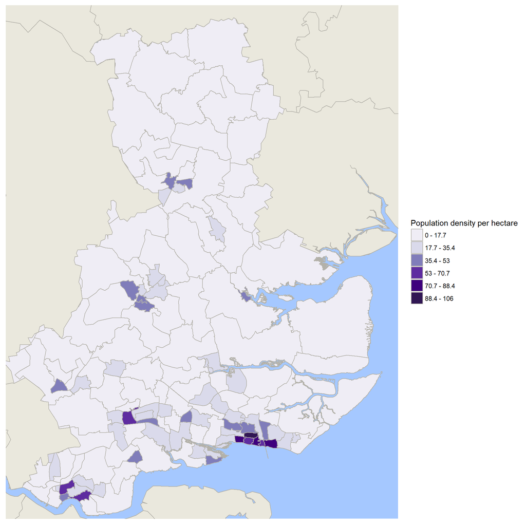

**Figure 2**: Population density per hectare by postal sector in the STP

<sup>Contains OS data © Crown copyright and database right (2018)</sup> <sup>Source: Office for National Statistics</sup> <sup>Contains public sector information licensed under the Open Government Licence v3.0.</sup>

Looking forward, in the five years between 2016 and 2021 the population in the region is expected to grow from 1.17 million residents to just over 1.2 million, or at a compounded rate of 0.76% per year. By 2039 the population is forecast to reach just over 1.37 million people, which represents an annual compound growth rate of 0.7% per year. Table 1 also shows the current and forecast population for each of the CCGs involved in the STP<sup>6</sup>.

**Table 1**: Current population (2016) and forecast population in 2021 and 2039 by CCG.

| CCG | 2016 | 2021 * | 2039 * |
| --- | --- | --- | --- |
| NHS Mid Essex | 389 | 402 | 448 |
| NHS Basildon and Brentwood | 260 | 271 | 311 |
| NHS Southend | 181 | 188 | 214 |
| NHS Castle Point, Rayleigh and Rochford | 175 | 179 | 196 |
| NHS Thurrock | 167 | 176 | 208 |
| **Total** | **1,171** | **1,217** | **1,376** |

<sup>Source: Office for National Statistics</sup> <sup>Contains public sector information licensed under the Open Government Licence v3.0.</sup>

According to Table 1, each of the CCGs are forecast to grow over the coming years. In the five years from 2016, Thurrock CCG is expected to grow at a compound rate of 1.11%, which is far higher than any of the other CCGs in the STP (the second highest CCG - Basildon and Brentwood - will grow at a rate of 0.85%). The slowest growing CCG is Castle Point, Rochford and Rayleigh CCG, which is expected to grow at an annual rate of 0.43%. In relative terms, between 2016 and 2021, the population in the STP will grow by just under 4%, and between 2016 and 2039 the population is forecast to have grown by 17.5%.

Overall the compound growth in the region (0.76%) is expected to be slightly higher than the national average rate of 0.72% for the five years from 2016. However, over the longer term, up until 2039, the national compound growth rate will be 0.59% per year, while in the STP this rate will be 0.70% per year far outstripping the national rate<sup>6</sup>. Considering these points, any health transformations that take place in the region must, at the very least, plan services that take into account this growth - especially over the longer term.

Having considered where the current population resides and how the population will grow in the coming years it is also important to understand the make-up of the population, including the population’s age profile. This is considered next.

### Age overview - how old is the population?

Different aged users have different healthcare needs and it is important for the health system to provide not only the right sized services for the age groups it serves, but also provide services in the right locations - ideally near to where there is demand for a particular service. For example, there is little value in placing a community maternity unit in an area where most of the residents are aged over 60, likewise there would be little value in placing an elective orthopaedic centre in the middle of a town, where the population tends to be younger. This section will aide us get a better understanding of the population’s age distribution and their location in the STP area.

Based on the Office for National Statistics’ (ONS) mid-2016 population estimates, the median age in the STP area (41) is similar to that of the UK (40), indicating that, broadly speaking, the STP covers a typical age profile for the UK.

Figure 3, below, shows the median age band, as of the 2011 census, for each of the postal sectors in the region. While many of the postal sectors in the region are aged 40 or over (those coloured in shades of purple) there are several pockets of postal sectors interspersed throughout the region with a younger median age (those coloured in shades of green). These pockets are primarily near the centres of the region’s towns and cities and is a common occurrence throughout the UK.

There are only two postal sectors in the region that have a median age in the 25-30 age band. One of these sectors is in Thurrock, surrounding Tilbury docks and the other is in the centre of Chelmsford and includes Anglia Ruskin University’s Chelmsford campus. Docks tend to attract a younger workforce, while university students tend to be younger than 25, explaining why these two postal sectors have such a young median age.

At the other extreme, there are only three postal sectors where the median age is in the 50-55 age band. One sector is located to the very north of the STP region while the other two sectors are in the south. The sector in the north is sparsely populated and made up of several small villages. This postal sector also crosses CCG boundaries with the majority of the postal sector (and population) laying outside of the STP region. In the south, one of the sectors is situated on Canvey Island while the other is in the Thorpe Bay area of Southend. The sector on Canvey Island includes a large static home park, which tend to attract a more elderly population<sup>7</sup>, providing an explanation for the sectors higher median age, while Thorpe Bay is known within the region, to be a more affluent seafront retirement destination.

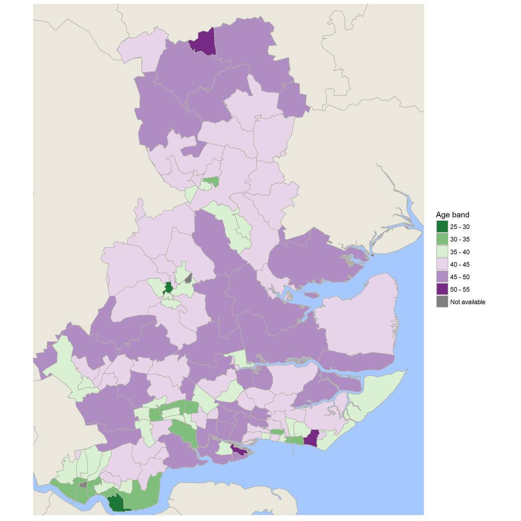

**Figure 3**: Map of the median age band by postal sector in the STP

<sup>Contains OS data © Crown copyright and database right (2018)</sup> <sup>Source: Office for National Statistics</sup> <sup>Contains public sector information licensed under the Open Government Licence v3.0.</sup>

The median age provides an overall sense of a postal sectors age make-up, however to get a better understanding of the region’s age make-up, in terms of locating health services - especially community based services, it is important to contrast the median age with the percentage of the population in each postal sector that are elderly (here defined as 75 and over) and young (defined as under 18). Figures 4 and 5 show the relative percentage of elderly and young people in each of the STP’s postal sector, respectively.

In Figure 5 we can see that the University postal sector near the centre of Chelmsford has the lowest proportion of young people than any other postal sector in the STP region - around 11%. This further reinforces the idea that this postal sector is predominately made up of students: a low median age range, very few under 18s and only between 5-9% of the sector’s population is aged over 75.

Although the median age towards the very north of the STP is in the second highest age band (45-50), the percentage of residents aged 75 and over in these postal sectors is relatively low, only between 5-9%. This indicates that while the make-up of these postal sectors is skewed towards those residents aged 45 and over the more elderly residents are under represented - potentially owing to the rurality of some of these sectors. This is a similar story for the postal sector on Canvey with one of the highest overall median ages and a lower percentage of over 75s.

The Thurrock area, especially the area surrounding the docks has a much lower proportion of residents aged 75 and over, however as shown on Figure 5, this area has a much greater proportion of residents aged 18 and under - with two postal sectors showing between 30% and 34% of residents aged under 18, highlighting the fact that the Thurrock area has a much younger demographic and a higher proportion of children.

Other postal sectors with higher percentages of under 18s can be found around Southend, Basildon and Braintree. Interestingly, there is one postal sector towards the south-west of Braintree that has a very high proportion (30-34%) of under 18s and a very low proportion (0-5%) of over 75s. This postal sector covers the area of Great Notley a new garden village community developed between 1993 and 2017 by Countryside Properties, attracting a lot of families to the area<sup>8</sup>.

Clearly, there is a need to effectively locate the right type of health care services in the right area in order to meet that area’s current age profile. We have shown that the Thurrock area and town centres tend to have a younger demographic with a higher percentage of under 18s, suggesting that these areas could benefit from health services specialising in family health. We have also shown that the Thorpe Bay, Rayleigh/Thundersley and Brentwood areas have a higher proportion of over 75s indicating that these areas could benefit from specialist services focused on the elderly population. We highlighted the fact that although the very north of the region has a higher median age, the percentage of those residents aged over 75 is relatively low and finally, we also highlighted that it is vital that health care planners and providers liaise with housing and infrastructure development projects (Cross Rail and the second Thames crossing, for example) as these could drastically alter that area’s demographic profile, as evidenced by the Great Notley development.

So far, we have examined where people live and the population’s age profile, next we will consider the levels of deprivation present in the region, both in terms of overall deprivation and health deprivation.

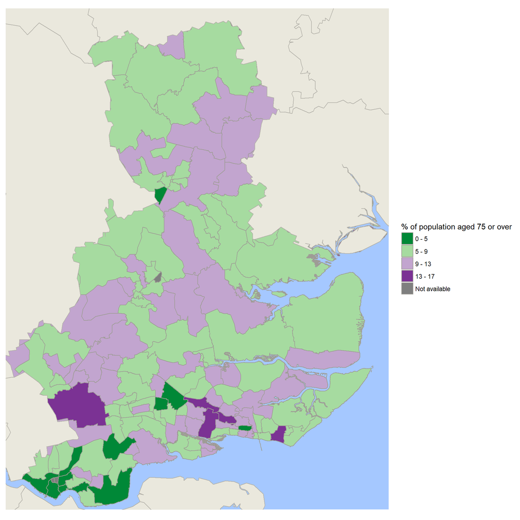

**Figure 4**: Map showing the percentage of people aged 75 or over by postal sector in the STP

<sup>Contains OS data © Crown copyright and database right (2018)</sup> <sup>Source: Office for National Statistics</sup> <sup>Contains public sector information licensed under the Open Government Licence v3.0.</sup>

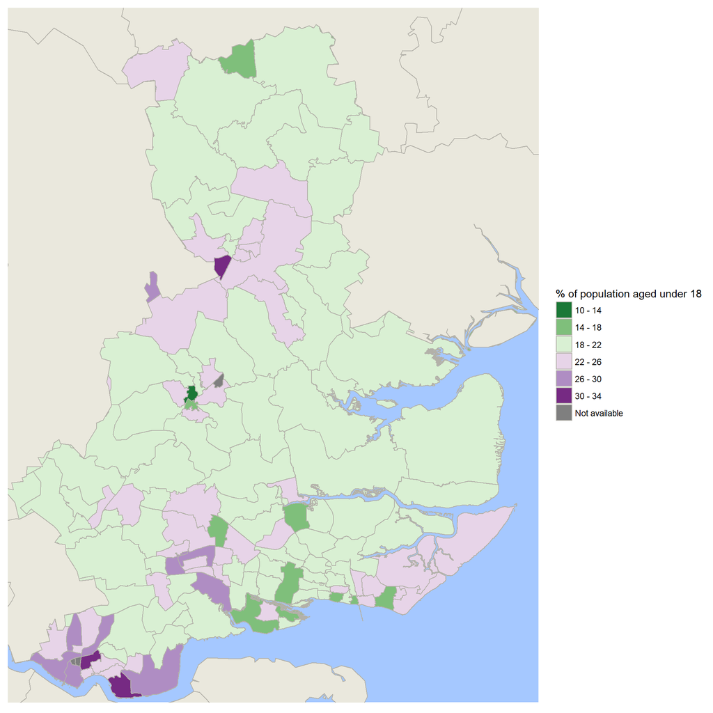

**Figure 5**: Map showing the percentage of people aged under 18 by postal sector in the STP

<sup>Contains OS data © Crown copyright and database right (2018)</sup> <sup>Source: Office for National Statistics</sup> <sup>Contains public sector information licensed under the Open Government Licence v3.0.</sup>

### Socio-economic and health deprivation

Having considered where people live and how old the population is, it is important to assess the levels of deprivation in the region. Deprivation measures the lack of material benefits deemed to be essential in a society and a higher level of deprivation has been shown to increase the use of health care services<sup>9</sup>.

Deprivation in England is measured through the Index of Multiple Deprivations (IMD), an official statistic produced by the Ministry of Housing, Communities and Local Government<sup>10</sup>. This is a composite indicator and measures deprivation across seven aspects namely: income, employment, health and disability, education skills and training, barriers to housing and services, crime and, finally, living environment. The IMD is produced at the Lower-layer Super Output Area (neighbourhoods) level, a level that is designed to be of a similar population size - an average of 1,500 residents<sup>11</sup>.

It is important to note that the IMD measures deprivation and as such a neighbourhood that is in the least deprived decile is not necessarily an affluent area - a neighbourhood in the least deprived decile may have very few people claiming income benefits or tax credits but might not have any high earners<sup>11</sup>.

Figure 6 shows the latest (2015) IMD statistics for the STP region. It is clear that the region covers a wide range of deprivation levels with neighbourhoods in the top and bottom deciles of deprivation. Areas near town centres appear to be more deprived, in particular most neighbourhoods in Basildon, Southend and the outskirts of Grays are in the bottom third deciles of deprivation. At the other extreme there are clusters of neighbourhoods which are in the least deprived deciles, namely the areas surrounding Brentwood, Billericay and the neighbourhoods between Thundersley and Hockley.

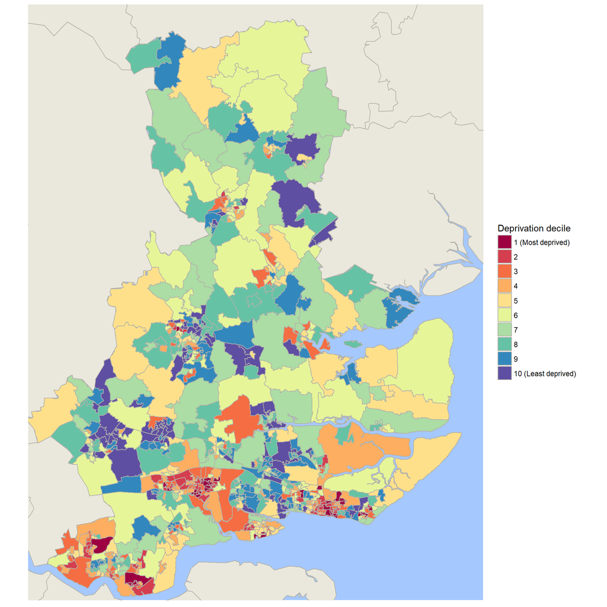

**Figure 6**: Map showing the deprivation deciles for each neighbourhood in the STP

<sup>Contains OS data © Crown copyright and database right (2018)</sup> <sup>Source: Office for National Statistics</sup> <sup>Contains public sector information licensed under the Open Government Licence v3.0.</sup>

We can contrast the overall levels of deprivation in the region with just the indicators belonging to the health and disability domain. Figure 7 shows the most recent deprivation levels for this domain. Again, this domain is a combination of several health indicators measuring the risk of premature death and the impairment of quality of life as a result of poor physical or mental health. Interestingly, one of the indicators in the domain takes into account a standardised measure of emergency hospital admissions<sup>11</sup>.

We can see from Figure 7 that there are far more neighbourhoods in the least deprived decile for this domain than in the overall deprivation levels shown in Figure 6. However, the area surrounding Tilbury docks remains in the lower half of the health deprivation deciles. The most deprived areas within the health domain are Basildon and Southend, with both areas having neighbourhoods in the most deprived health decile. Figures 8 and 9 provide a more detailed view of the Southend and Basildon areas, respectively.

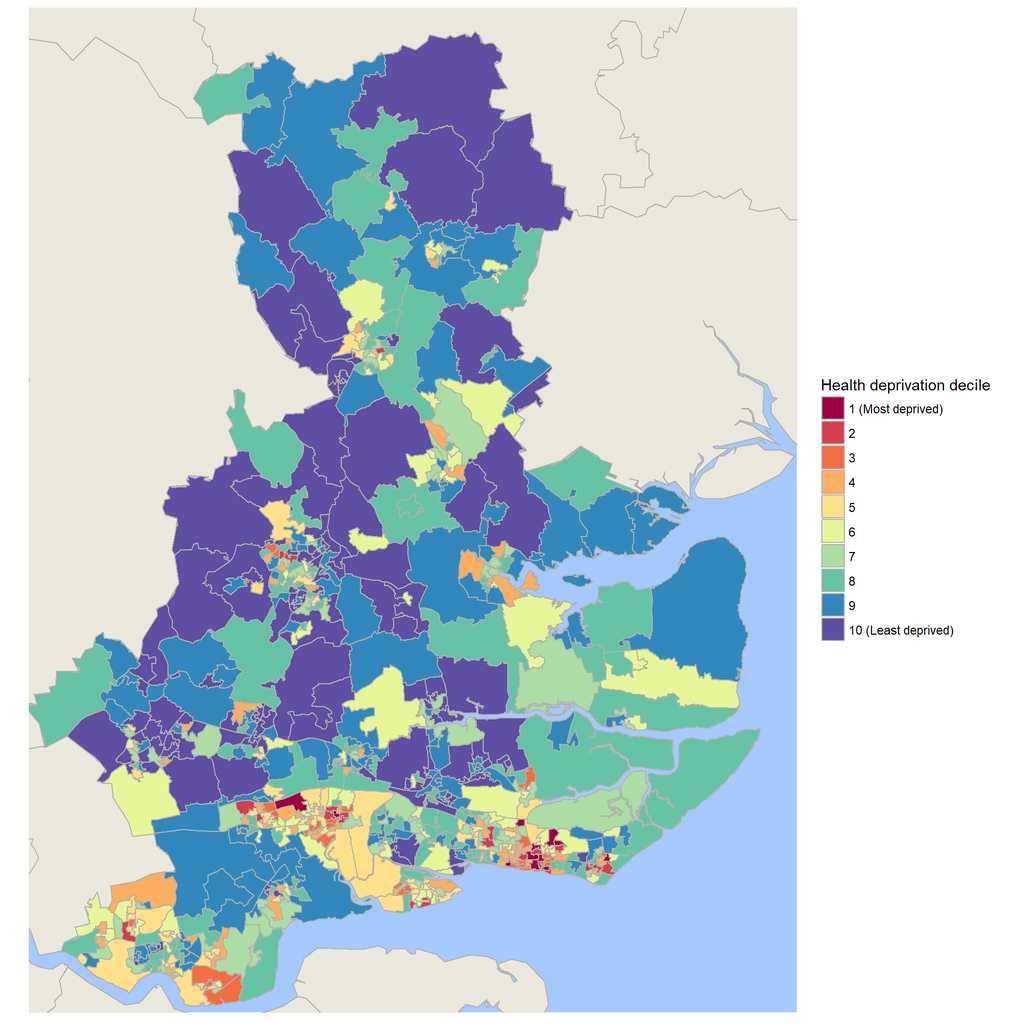

**Figure 7**: Map showing the levels of deprivation for the health domain indicators for each neighbourhood in the STP

<sup>Contains OS data © Crown copyright and database right (2018)</sup> <sup>Source: Office for National Statistics</sup> <sup>Contains public sector information licensed under the Open Government Licence v3.0.</sup>

In Southend (Figure 8) the most health deprived neighbourhoods are those that surround the main high street down to the pier and the neighbourhoods surrounding Shoeburyness. Interestingly, within the Southend region, there are also areas in the least health deprived decile, namely the neighbourhoods surrounding Leigh-on-Sea and Thorpe Bay.

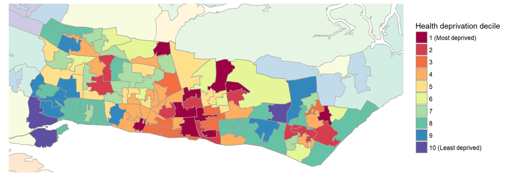

**Figure 8**: Map showing the levels of health deprivation for Southend neighbourhoods

<sup>Contains OS data © Crown copyright and database right (2018)</sup> <sup>Source: Office for National Statistics</sup> <sup>Contains public sector information licensed under the Open Government Licence v3.0.</sup>

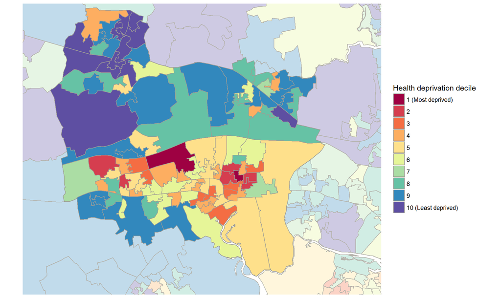

**Figure 9**: Map showing the levels of health deprivation for Basildon Neighbourhoods

<sup>Contains OS data © Crown copyright and database right (2018)</sup> <sup>Source: Office for National Statistics</sup> <sup>Contains public sector information licensed under the Open Government Licence v3.0.</sup>

These two areas highlight the challenges healthcare planners will face in providing the right healthcare services in the right areas - even within a relatively small area there can be very large variations in health deprivation. To better understand this variation, we will examine nationally benchmarked indicators published by Public Health England (PHE) for each of the districts in the STP.

#### PHE indicators

The Excess Winter Death indicator (Table 2) is designed to measure the number of extra deaths, from all causes, that occur in the winter months compared to the average number of deaths that occur in the non-winter months<sup>12</sup>. As we can see, none of the districts perform significantly worse than nationally and two districts, Brentwood and Rochford, even perform significantly better than nationally. The worse performing district in the STP is Braintree. Although there is large variation in the performance across the districts and work can be done to improve the performance of those districts that are higher than the national average, excess deaths relating to winter does not appear to be a major problem is the STP area.

#### Excess winter deaths

**Table 2**: Excess winter deaths by district (Aug 2013 - Jul 2016)

| District | Excess Winter Deaths Index | Chart |
| --- | --- | --- |
| Basildon | 16 |  |
| Castle Point | 19 |  |
| Southend | 15 |  |
| Thurrock | 18 |  |
| Braintree | 22 |  |
| Brentwood | 6.9 |  |
| Rochford | 6.3 |  |
| Chelmsford | 19 |  |
| Maldon | 11 |  |

<sup>Contains public sector information licensed under the Open Government Licence v3.0.</sup>

Tables 3 and 4 present the age standardised mortality rates for cancer and cardiovascular disease - two major causes of death for those aged under 75 in England. Again, there is large variation in performance across the districts, however this time there are districts that are significantly worse than the national average, namely Thurrock for cardiovascular deaths and Basildon for cancer deaths. Work will need to be done to bring these two districts within normal ranges, however, reassuringly in terms of cardiovascular deaths, five out of the nine districts in the STP are performing significantly better than nationally. The Rochford and Chelmsford districts are performing significantly better than nationally in terms of cancer mortality rates.

#### Under 75 deaths: Cardiovascular

**Table 3**: Age standardised mortality rates per 100,000 population for cardiovascular disease by district

| District | Age standardised mortality rate per 100,000 population | Chart |
| --- | --- | --- |
| Basildon | 73 |  |
| Castle Point | 67 |  |
| Southend | 77 |  |
| Thurrock | 86 |  |
| Braintree | 59 |  |
| Brentwood | 53 |  |
| Rochford | 53 |  |
| Chelmsford | 54 |  |
| Maldon | 59 |  |

<sup>Contains public sector information licensed under the Open Government Licence v3.0.</sup>

#### Under 75 deaths: Cancer

**Table 4**: Age standardised mortality rates per 100,000 population for cancer by district

| District | Age standardised mortality rate per 100,000 population | Chart |
| --- | --- | --- |
| Basildon | 155 |  |
| Castle Point | 143 |  |
| Southend | 139 |  |
| Thurrock | 148 |  |
| Braintree | 133 |  |
| Brentwood | 127 |  |
| Rochford | 115 |  |
| Chelmsford | 119 |  |
| Maldon | 124 |  |

<sup>Contains public sector information licensed under the Open Government Licence v3.0.</sup>

Table 5 presents the age standardised mortality rates for hip fractures in people aged over 65 for each of the districts in the STP. Hip fractures are a serious condition that is set to increase over the coming years as the population continues to age<sup>13</sup>. They also incur a significant health and social care cost - approximately £26,000 per hip fracture<sup>13</sup>. Therefore, any successful health economy would need to effectively manage, and seek to reduce, the occurrence of, hip fractures and the related comorbidities.

Currently, eight out of the nine districts in the STP are within the expected national range, however only one district is marginally lower than the national average rate (Basildon). One district, Thurrock, is significantly higher than the national rate, which is interesting bearing in mind the relatively younger age profile of this district. This could potentially indicate a district that is not equipped to deal with hip fractures effectively and there may be some benefit to collaborating with neighbouring districts that have more experience in this area in order to improve patient outcomes over the longer term. Clearly, work needs to happen in this area if the health economy is going to succeed in the long run.

#### Hip fracture in people aged 65 and over

**Table 5**: Age standardised mortality rates per 100,000 population for hip fractures in people aged 65 and over by district

| District | Age standardised mortality rate per 100,000 population | Chart |
| --- | --- | --- |
| Basildon | 535 |  |
| Castle Point | 669 |  |
| Southend | 602 |  |
| Thurrock | 731 |  |
| Braintree | 621 |  |
| Brentwood | 592 |  |
| Rochford | 594 |  |
| Chelmsford | 594 |  |
| Maldon | 633 |  |

<sup>Contains public sector information licensed under the Open Government Licence v3.0.</sup>

One of the key ways to measure the overall trend in population health is by examining the healthy life expectancy at birth. This life expectancy is calculated based upon the current mortality rates for that district.

Table 6 presents this information, split by gender, for each of the districts in the STP. There are several districts where the life expectancy for both males and females is significant higher than the average for England, namely the districts of Brentwood, Rochford and Chelmsford. The male life expectancy in Braintree is also significantly higher, although the female life expectancy is within the expected range. The districts of Maldon and Castle Point have a similar life expectancy to the average for England for both males and females. However, the districts of Basildon, Thurrock and Southend, the three main districts highlighted in previous section as being in the bottom deciles of overall deprivation (see Figure 6), all have one of the two genders’ life expectancies in the significantly worse than average for England category. For both Basildon and Thurrock, the female life expectancy is significantly worse than the national average, while in Southend it is the male life expectancy.

The life expectancy table again highlights the amount of variation that is present in the STP region. Between the districts with the highest and lowest life expectancies in the STP there is just over a 2.5-year difference, irrespective of gender. Clearly, there is work that needs to be done in the STP area to reduce health inequalities.

#### Life expectancy at birth

**Table 6**: Male and female life expectancy at birth using current mortality rates by district

| District | Life expectancy | Chart |
| --- | --- | --- |
| **Basildon** |  |  |
| Male | 79.8 |  |
| Female | 82.6 |  |
| **Castle Point** |  |  |
| Male | 79.7 |  |
| Female | 82.7 |  |
| **Southend** |  |  |
| Male | 78.6 |  |
| Female | 82.9 |  |
| **Thurrock** |  |  |
| Male | 79.1 |  |
| Female | 82.3 |  |
| **Braintree** |  |  |
| Male | 80.5 |  |
| Female | 83 |  |
| **Brentwood** |  |  |
| Male | 81.1 |  |
| Female | 84.3 |  |
| **Rochford** |  |  |
| Male | 81.3 |  |
| Female | 84.9 |  |
| **Chelmsford** |  |  |
| Male | 81.3 |  |
| Female | 84.6 |  |
| **Maldon** |  |  |
| Male | 80.2 |  |
| Female | 83.5 |  |

<sup>Contains public sector information licensed under the Open Government Licence v3.0.</sup>

## Conclusion - end of part I

This post focused on the demand side of the healthcare supply and demand equation for the Mid and South Essex STP region. Our primary aim for this first post was to get a better understanding of the different demographics present throughout the region and how these might drive healthcare demand - the first factor in our overall analysis.

Before examining the demographics, we started by explaining the national objectives of STPs and how success regimes are special cases of these. We then presented the Mid and South Essex’s STP geography, as well as, the main organisations involved in the partnership.

We then moved on to examine our first demographic criteria - population density - and found that although the majority of the region is relatively sparsely populated, there are pockets of much higher density. In particular, the regions surrounding the main towns and cities were more densely populated and we observed that the overall population is more concentrated in the south of the region.

Next, we examined the age of the population and found that the median age was similar to the rest of England. We observed that there is a concentration of people aged 75 and over in the areas surrounding Thrope Bay, Brentwood and Rayleigh and that there is a concentration of younger people in the Thurrock and Grays area and in the Great Notley development. New developments like Great Notley can drastically alter the demographics in a region and we noted that healthcare planners need to pay special attention to these, especially as new infrastructure is planned for the area.

Finally, we examined the socio-economic make-up of the population through the Index of Multiple Deprivations and, for each district in the STP, we examined a selection of current Public Health metrics. From the IMD map (Figure 6) we observed that the levels of deprivation varied widely - there were neighbourhoods in every decile of the index. However, when examining just the health domain of the index, more neighbourhoods appeared to be in the upper deciles, with the exception of town centres, in particular Basildon and Southend, which continued to be in the lower deciles.

In terms of the Public Health indicators we observed that for certain indicators several districts were performing significantly better than England, for example the regions of Brentwood, Rochford and Chelmsford in terms of life expectancy, while other areas were performing significantly worse, Southend for male life expectancy, and Thurrock and for female life expectancy.

Overall, the STP region is a diverse region with a large amount of variability across all demographics, however, as we have seen, these extremes cluster around certain areas in the STP. Therefore, for the health economy to succeed - financially and in term of meeting the needs of the current and future population - it is paramount that the right type and size of services are in the right locations.

The second part of this post will focus on the current supply of healthcare services (factors two through four presented in the introduction) examining the number of and quality ratings for the hospital, GP and social care provision in the region. We will also look at the location of these services, the fifth factor, and examine their proximity to users.

### References

<sup>1</sup> ONS, Mid 2016 population estimates https://www.ons.gov.uk/peoplepopulationandcommunity/populationandmigration/populationestimates/datasets/populationestimatesforukenglandandwalesscotlandandnorthernireland

<sup>2</sup>https://www.england.nhs.uk/five-year-forward-view/

<sup>3</sup>https://www.england.nhs.uk/systemchange/view-stps/

<sup>4</sup>http://www.nhsmidandsouthessex.co.uk/about-the-stp/whos-involved/

<sup>5</sup>http://www.nhsmidandsouthessex.co.uk/background/further-information/

<sup>6</sup>ONS: Mid 2016 CCG population estimates https://www.ons.gov.uk/peoplepopulationandcommunity/populationandmigration/populationestimates/datasets/clinicalcommissioninggroupmidyearpopulationestimates

<sup>7</sup>http://researchbriefings.parliament.uk/ResearchBriefing/Summary/SN01080

<sup>8</sup>https://www.countryside-properties.com/about-us/housebuilding/case-studies/strategic-land/great-notley-garden-village-essex/

<sup>9</sup>http://jech.bmj.com/content/54/4/306

<sup>10</sup>https://www.gov.uk/government/statistics/english-indices-of-deprivation-2015

<sup>11</sup>https://www.gov.uk/government/publications/english-indices-of-deprivation-2015-technical-report

<sup>12</sup>http://fingertips.phe.org.uk/

<sup>13</sup>https://www.nice.org.uk/guidance/cg124/evidence/full-guideline-183081997